# Data Analyzation Project in R for Google Data Analyzation Course

### Correlation between number of entries and calories

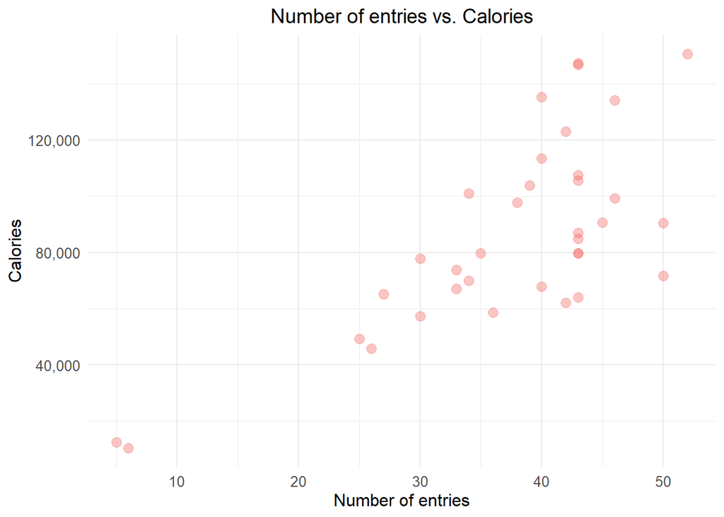

```r
chart_7 <- ggplot(sums_by_id, aes(x = count_by_id, y = total_calories_by_id)) +
  geom_point(color = rgb(242, 92, 84, maxColorValue = 255, alpha = 90), size = 3) +
  scale_y_continuous(labels = scales::comma) +
  labs(
    title = "Number of entries vs. Calories",
    x = "Number of entries",
    y = "Calories"
  ) +
  theme_minimal() +
  theme(
    axis.text.y = element_text(size = 10, angle = 0, vjust = 0.5),
    axis.title = element_text(size = 12),
    plot.title = element_text(hjust = 0.5, size = 14),
    axis.text.x = element_text(size = 10)
  )

chart_7
```

```r
ggsave("entries_vs_calories.jpeg", plot=chart_7, path = '~/bellabeat_project/Figures')

cor(sums_by_id$total_calories_by_id, sums_by_id$count_by_id)
```

```
## [1] 0.7268304
```

The positive correlation values indicate that higher number of entries result in higher total steps, distance and burned calories.

### Correlation matrix between number of entries, distancies, activness and calories

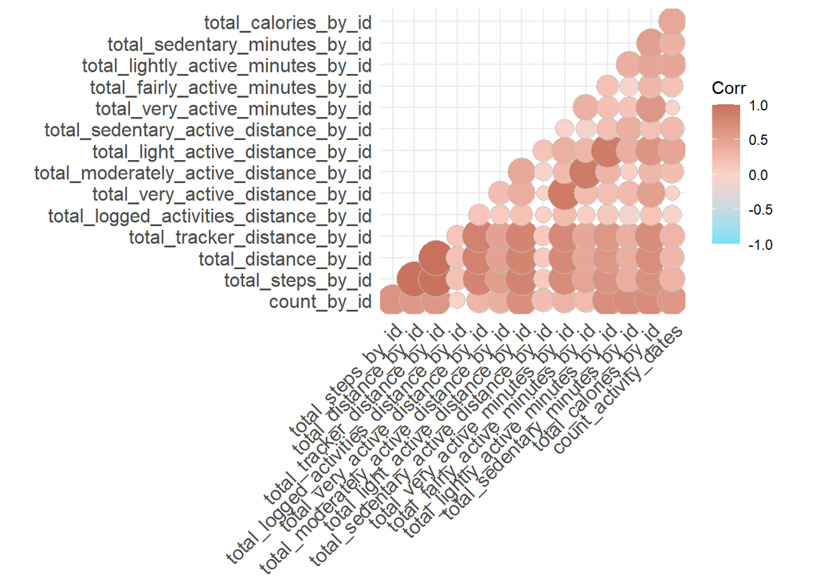

```r
correlation_matrix <- cor(sums_by_id[,unlist(lapply(sums_by_id, is.numeric))])

##chart_8 <- corrplot(correlation_matrix, type = "lower",
         ##tl.col = "black", tl.srt = 45, col=colorRampPalette(c("white","pink", "red"))(10))

chart_8 <- ggcorrplot(correlation_matrix,
           method = "circle",
           type = "lower",
           colors = c("#76e1fa", "#fdd2c8", "#c8725e"))

chart_8
```

```r
ggsave("activity_correlation_matrix.jpeg", plot=chart_8, path = '~/bellabeat_project/Figures')
```

This figure shows the strength of correlation between the variables, so we can see that there is a strong correlation between the number of entries and performance, as well as between the performance and the calories.

## Analyzing calories

### Calorie data

Daily calories

```r
# reading data

dailyCalories_clean <- read.csv("~/bellabeat_project/Clean_tables/dailyCalories_clean.csv")

# explore data
##glimpse(dailyCalories_clean)
dailyCalories_clean$Id <- as.character(dailyCalories_clean$Id)
##skimr::skim(dailyCalories_clean)
```

Hourly Calories

```r
# reading data

hourlyCalories_clean <- read.csv("~/bellabeat_project/Clean_tables/hourlyCalories_clean.csv")

# explore data
##glimpse(hourlyCalories_clean)
hourlyCalories_clean$Id <- as.character(hourlyCalories_clean$Id)
##skimr::skim(hourlyCalories_clean)

cat('Dates of entries:', levels(as.factor(hourlyCalories_clean$Date)))
```

```
## Dates of entries: 3/12/2016 4/12/2016 5/12/2016
```

```r
hourlyCalories_clean$Hour_simple <- paste(sub(':.*$','', hourlyCalories_clean$Hour), hourlyCalories_clean$AM_PM)
##head(hourlyIntensities)
```

Minute Calories

```r
print('Minute Calories Narrow')
```

```
## [1] "Minute Calories Narrow"
```

```r
# reading data

minuteCaloriesNarrow_clean <- read.csv("~/bellabeat_project/Clean_tables/minuteCaloriesNarrow_clean.csv")

# explore data
##glimpse(minuteCaloriesNarrow_clean)
minuteCaloriesNarrow_clean$Id <- as.character(minuteCaloriesNarrow_clean$Id)
##skimr::skim(minuteCaloriesNarrow_clean)

cat('Dates of entries:', levels(as.factor(minuteCaloriesNarrow_clean$Date)))
```

```
## Dates of entries: 3/12/2016 4/12/2016 5/12/2016
```

```r
print('Minute Calories Wide')
```

```
## [1] "Minute Calories Wide"
```

```r
# reading data

minuteCaloriesWide_clean <- read.csv("~/bellabeat_project/Clean_tables/minuteCaloriesWide_clean.csv")

# explore data
##glimpse(minuteCaloriesWide_clean)
minuteCaloriesWide_clean$Id <- as.character(minuteCaloriesWide_clean$Id)
##skimr::skim(minuteCaloriesWide_clean)

cat('Dates of entries:', levels(as.factor(minuteCaloriesWide_clean$Date)))
```

```
## Dates of entries: 4/12/2016 5/12/2016
```

### Daily calory entries

In daily calories and wide minute calories data frame there are only two days, while hourly calories and minute calories narrow data frame contain data for all three days, so daily entries are derived from those tables and analyzation is conducted based on them.

```r
daily_calorie_entries <- hourlyCalories_clean %>% group_by(Date) %>%  summarize(count_by_Id = n())
kable(daily_calorie_entries)
```

| Date | count_by_Id |
| --- | --- |
| 3/12/2016 | 8165 |
| 4/12/2016 | 12384 |
| 5/12/2016 | 4690 |

```r
cat("Average number of calory entries: ", mean(daily_calorie_entries$count_by_Id))
```

```
## Average number of calory entries:  8413
```

### Calorie entries by Id

```r
calorie_entries_by_id <- hourlyCalories_clean %>% group_by(Id) %>%  summarize(count_by_Id = n())
sorted_calorie_entries_by_id <- calorie_entries_by_id[order(calorie_entries_by_id$count_by_Id, decreasing = TRUE),]
kable(sorted_calorie_entries_by_id)
```

| Id | count_by_Id |
| --- | --- |
| 8378563200 | 1073 |
| 5577150313 | 1057 |
| 1503960366 | 1030 |
| 4445114986 | 986 |
| 4702921684 | 982 |
| 8877689391 | 973 |
| 6962181067 | 960 |
| 5553957443 | 946 |
| 1644430081 | 941 |
| 2873212765 | 935 |
| 7086361926 | 913 |
| 8053475328 | 870 |
| 4319703577 | 864 |
| 2026352035 | 840 |
| 6117666160 | 834 |
| 4558609924 | 827 |
| 2022484408 | 812 |
| 7007744171 | 810 |
| 1624580081 | 782 |
| 2347167796 | 774 |
| 3977333714 | 754 |
| 3372868164 | 748 |
| 1927972279 | 678 |
| 8583815059 | 620 |
| 4020332650 | 581 |
| 4388161847 | 554 |
| 6290855005 | 547 |
| 8792009665 | 541 |
| 2320127002 | 540 |
| 6775888955 | 452 |
| 1844505072 | 406 |
| 8253242879 | 306 |
| 4057192912 | 224 |
| 6391747486 | 67 |
| 2891001357 | 12 |

```r
cat("Average number of calory entries: ", mean(calorie_entries_by_id$count_by_Id))
```

```
## Average number of calory entries:  721.1143
```

### Daily calory entries by Id

```r
daily_calorie_entries_by_id <- hourlyCalories_clean %>% group_by(Id, Date) %>%  summarize(count_by_Id = n())
kable(daily_calorie_entries_by_id)
```

| Id | Date | count_by_Id |
| --- | --- | --- |
| 1503960366 | 3/12/2016 | 337 |
| 1503960366 | 4/12/2016 | 486 |
| 1503960366 | 5/12/2016 | 207 |
| 1624580081 | 3/12/2016 | 250 |
| 1624580081 | 4/12/2016 | 359 |
| 1624580081 | 5/12/2016 | 173 |
| 1644430081 | 3/12/2016 | 355 |
| 1644430081 | 4/12/2016 | 406 |
| 1644430081 | 5/12/2016 | 180 |
| 1844505072 | 3/12/2016 | 47 |
| 1844505072 | 4/12/2016 | 302 |
| 1844505072 | 5/12/2016 | 57 |
| 1927972279 | 3/12/2016 | 333 |
| 1927972279 | 4/12/2016 | 274 |
| 1927972279 | 5/12/2016 | 71 |
| 2022484408 | 3/12/2016 | 268 |
| 2022484408 | 4/12/2016 | 385 |
| 2022484408 | 5/12/2016 | 159 |
| 2026352035 | 3/12/2016 | 276 |
| 2026352035 | 4/12/2016 | 371 |
| 2026352035 | 5/12/2016 | 193 |
| 2320127002 | 3/12/2016 | 70 |
| 2320127002 | 4/12/2016 | 317 |
| 2320127002 | 5/12/2016 | 153 |
| 2347167796 | 3/12/2016 | 350 |
| 2347167796 | 4/12/2016 | 424 |
| 2873212765 | 3/12/2016 | 314 |
| 2873212765 | 4/12/2016 | 433 |
| 2873212765 | 5/12/2016 | 188 |
| 2891001357 | 4/12/2016 | 12 |

[output cut: 68 more lines]

### Average daily calory entries by Id

```r
average_daily_entries_by_id <- daily_calorie_entries_by_id %>%
  group_by(Id) %>%
  summarize(mean_daily_entries = mean(count_by_Id), days = n())
##kable(average_daily_entries_by_id)

calorie_entries_by_id <- hourlyCalories_clean %>% group_by(Id) %>%  summarize(count_by_Id = n())

calorie_data_by_id <- merge(calorie_entries_by_id, average_daily_entries_by_id, by = "Id")
sorted_calorie_data_by_id <- calorie_data_by_id[order(calorie_data_by_id$count_by_Id, decreasing = TRUE),]
kable(sorted_calorie_data_by_id, row.names = FALSE)
```

| Id | count_by_Id | mean_daily_entries | days |
| --- | --- | --- | --- |
| 8378563200 | 1073 | 357.6667 | 3 |
| 5577150313 | 1057 | 352.3333 | 3 |
| 1503960366 | 1030 | 343.3333 | 3 |
| 4445114986 | 986 | 328.6667 | 3 |
| 4702921684 | 982 | 327.3333 | 3 |
| 8877689391 | 973 | 324.3333 | 3 |
| 6962181067 | 960 | 320.0000 | 3 |
| 5553957443 | 946 | 315.3333 | 3 |
| 1644430081 | 941 | 313.6667 | 3 |
| 2873212765 | 935 | 311.6667 | 3 |
| 7086361926 | 913 | 304.3333 | 3 |
| 8053475328 | 870 | 290.0000 | 3 |
| 4319703577 | 864 | 288.0000 | 3 |
| 2026352035 | 840 | 280.0000 | 3 |
| 6117666160 | 834 | 278.0000 | 3 |
| 4558609924 | 827 | 275.6667 | 3 |
| 2022484408 | 812 | 270.6667 | 3 |
| 7007744171 | 810 | 270.0000 | 3 |
| 1624580081 | 782 | 260.6667 | 3 |
| 2347167796 | 774 | 387.0000 | 2 |
| 3977333714 | 754 | 251.3333 | 3 |
| 3372868164 | 748 | 249.3333 | 3 |
| 1927972279 | 678 | 226.0000 | 3 |
| 8583815059 | 620 | 206.6667 | 3 |
| 4020332650 | 581 | 193.6667 | 3 |
| 4388161847 | 554 | 277.0000 | 2 |
| 6290855005 | 547 | 182.3333 | 3 |
| 8792009665 | 541 | 180.3333 | 3 |
| 2320127002 | 540 | 180.0000 | 3 |
| 6775888955 | 452 | 150.6667 | 3 |
| 1844505072 | 406 | 135.3333 | 3 |
| 8253242879 | 306 | 153.0000 | 2 |
| 4057192912 | 224 | 112.0000 | 2 |
| 6391747486 | 67 | 33.5000 | 2 |
| 2891001357 | 12 | 12.0000 | 1 |

```r
cat("Average number of calorie entries: ", mean(calorie_entries_by_id$count_by_Id))
```

```
## Average number of calorie entries:  721.1143
```

```r
cat("Median of number of calorie entries: ", median(calorie_entries_by_id$count_by_Id))
```

```
## Median of number of calorie entries:  810
```

### Hourly average calories for all days and users

```r
hourly_average_calories <-
  hourlyCalories_clean %>% group_by(Hour_simple) %>%  summarize(average_hourly_calories = mean(Calories))

sorted_hourly_average_calories <- hourly_average_calories %>% arrange(factor(Hour_simple, levels = c('12 AM', '1 AM', '2 AM', '3 AM', '4 AM', '5 AM', '6 AM', '7 AM', '8 AM', '9 AM', '10 AM', '11 AM', '12 PM', '1 PM', '2 PM', '3 PM', '4 PM', '5 PM', '6 PM', '7 PM', '8 PM', '9 PM', '10 PM', '11 PM')))
kable(sorted_hourly_average_calories)
```

| Hour_simple | average_hourly_calories |
| --- | --- |
| 12 AM | 81.77760 |
| 1 AM | 78.82766 |
| 2 AM | 76.19014 |
| 3 AM | 73.13842 |
| 4 AM | 77.12813 |
| 5 AM | 91.42191 |
| 6 AM | 108.45527 |
| 7 AM | 113.74119 |
| 8 AM | 121.00089 |
| 9 AM | 123.44356 |
| 10 AM | 122.48779 |
| 11 AM | 122.77778 |
| 12 PM | 128.18454 |
| 1 PM | 123.93719 |
| 2 PM | 126.84786 |
| 3 PM | 118.14699 |
| 4 PM | 124.18359 |
| 5 PM | 130.97784 |
| 6 PM | 132.91620 |
| 7 PM | 133.78208 |
| 8 PM | 115.17753 |
| 9 PM | 106.50863 |
| 10 PM | 99.04089 |
| 11 PM | 88.49758 |

### Correlation between activity hour and calories

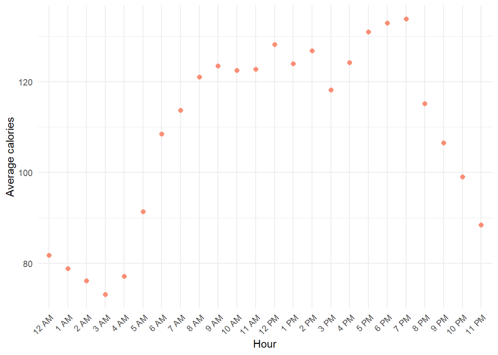

```r
chart_9 <- sorted_hourly_average_calories %>%
  mutate(Hour_simple = factor(Hour_simple, levels = unique(Hour_simple))) %>% ## keeping the order of the table
  ggplot(aes(x = Hour_simple, y = average_hourly_calories)) +
  geom_point(size = 2, color = "#fa8f76") +
  scale_x_discrete(guide = guide_axis(angle = 45)) + labs(x='Hour', y= 'Average calories')+
  theme_minimal()
ggsave("hourly_average_calories.jpeg", plot=chart_9, path = '~/bellabeat_project/Figures')
chart_9
```

## Analyzing intensities

### Intensitiy Data

Daily intensities

```r
# reading data

dailyIntensities_clean <- read.csv("~/bellabeat_project/Clean_tables/dailyIntensities_clean.csv")

# explore data
##glimpse(dailyCalories_clean)
dailyIntensities_clean$Id <- as.character(dailyIntensities_clean$Id)
##skimr::skim(dailyIntensities_clean)
```

Hourly intensities

```r
# reading data

hourlyIntensities <- read.csv("~/bellabeat_project/Clean_tables/hourlyIntensities_clean.csv")

# explore data
##glimpse(hourlyIntensities)
hourlyIntensities$Id <- as.character(hourlyIntensities$Id)
##skimr::skim(hourlyIntensities)

cat('Dates of entries:', levels(as.factor(hourlyIntensities$Date)))
```

```
## Dates of entries: 3/12/2016 4/12/2016 5/12/2016
```

```r
hourlyIntensities$Hour_simple <- paste(sub(':.*$','', hourlyIntensities$Hour), hourlyIntensities$AM_PM)
##head(hourlyIntensities)
```

### Hourly average intensities for all days and user

```r
hourly_average_intensities <-
  hourlyIntensities %>% group_by(Hour_simple) %>%  summarize(average_hourly_intensities = mean(TotalIntensity))

sorted_hourly_average_intensities <- hourly_average_intensities %>% arrange(factor(Hour_simple, levels = c('12 AM', '1 AM', '2 AM', '3 AM', '4 AM', '5 AM', '6 AM', '7 AM', '8 AM', '9 AM', '10 AM', '11 AM', '12 PM', '1 PM', '2 PM', '3 PM', '4 PM', '5 PM', '6 PM', '7 PM', '8 PM', '9 PM', '10 PM', '11 PM')))
kable(sorted_hourly_average_intensities)
```

| Hour_simple | average_hourly_intensities |
| --- | --- |
| 12 AM | 7.274354 |
| 1 AM | 5.439791 |
| 2 AM | 4.241590 |
| 3 AM | 2.867924 |
| 4 AM | 3.127737 |
| 5 AM | 10.511696 |
| 6 AM | 17.036244 |
| 7 AM | 19.488180 |
| 8 AM | 24.055378 |
| 9 AM | 24.352390 |
| 10 AM | 24.204683 |
| 11 AM | 23.457338 |
| 12 PM | 25.735341 |
| 1 PM | 24.133499 |
| 2 PM | 24.781893 |
| 3 PM | 20.807660 |
| 4 PM | 22.812808 |
| 5 PM | 26.135004 |
| 6 PM | 26.239617 |
| 7 PM | 27.308247 |
| 8 PM | 20.681223 |
| 9 PM | 17.919483 |
| 10 PM | 15.000000 |
| 11 PM | 11.646512 |

### Correlation between activity hour and intensities

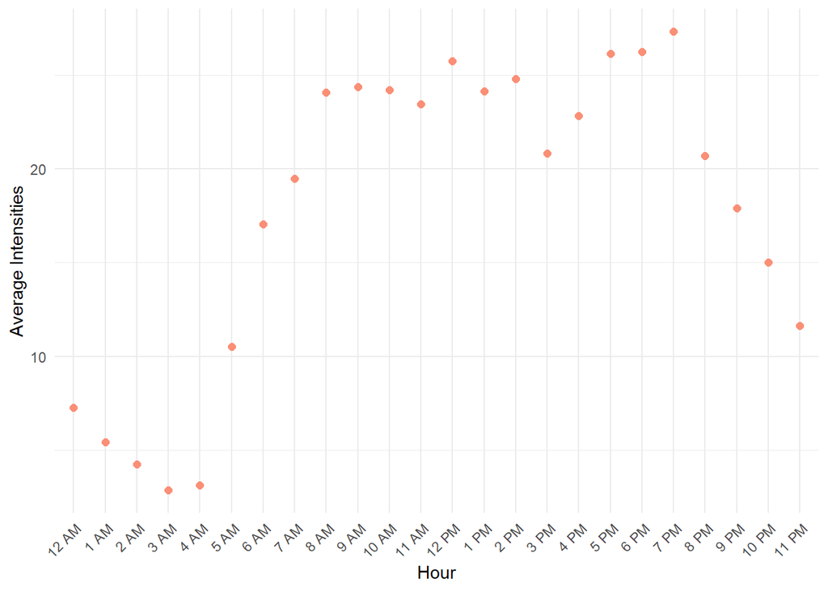

```r
chart_10 <- sorted_hourly_average_intensities %>%
  mutate(Hour_simple = factor(Hour_simple, levels = unique(Hour_simple))) %>% ## keeping the order of the table
  ggplot(aes(x = Hour_simple, y = average_hourly_intensities)) +
  geom_point(size = 2, color = "#fa8f76") +
  scale_x_discrete(guide = guide_axis(angle = 45)) + labs(x='Hour', y= 'Average Intensities') +
  theme_minimal()
ggsave("hourly_intensities.jpeg", plot=chart_10, path = '~/bellabeat_project/Figures')
chart_10
```

## Analyzing steps

### Steps data

Daily steps

```r
# reading data

dailySteps <- read.csv("~/bellabeat_project/Clean_tables/dailySteps_clean.csv")

# explore data
##glimpse(dailySteps)
dailySteps$Id <- as.character(dailySteps$Id)
##skimr::skim(dailySteps)
```

Hourly steps

```r
# reading data

hourlySteps<- read.csv("~/bellabeat_project/Clean_tables/hourlySteps_clean.csv")

# explore data
##glimpse(hourlySteps)
hourlySteps$Id <- as.character(hourlySteps$Id)
##skimr::skim(hourlySteps)

cat('Dates of entries:', levels(as.factor(hourlySteps$Date)))
```

```
## Dates of entries: 3/12/2016 4/12/2016 5/12/2016
```

```r
hourlySteps$Hour_simple <- paste(sub(':.*$','', hourlySteps$Hour), hourlySteps$AM_PM)
##head(hourlySteps)
```

### Hourly average steps for all users and all days

```r
hourly_average_steps <-
  hourlySteps %>% group_by(Hour_simple) %>%  summarize(average_hourly_steps = mean(StepTotal))

sorted_hourly_average_steps <- hourly_average_steps %>% arrange(factor(Hour_simple, levels = c('12 AM', '1 AM', '2 AM', '3 AM', '4 AM', '5 AM', '6 AM', '7 AM', '8 AM', '9 AM', '10 AM', '11 AM', '12 PM', '1 PM', '2 PM', '3 PM', '4 PM', '5 PM', '6 PM', '7 PM', '8 PM', '9 PM', '10 PM', '11 PM')))
kable(sorted_hourly_average_steps)
```

| Hour_simple | average_hourly_steps |
| --- | --- |
| 12 AM | 123.91964 |
| 1 AM | 78.67736 |
| 2 AM | 58.75626 |
| 3 AM | 36.36872 |
| 4 AM | 58.59497 |
| 5 AM | 153.87185 |
| 6 AM | 354.47566 |
| 7 AM | 520.68780 |
| 8 AM | 634.39983 |
| 9 AM | 626.78896 |
| 10 AM | 611.60141 |
| 11 AM | 586.09085 |
| 12 PM | 662.24773 |
| 1 PM | 618.30144 |
| 2 PM | 640.80386 |
| 3 PM | 502.36877 |
| 4 PM | 586.83377 |
| 5 PM | 621.04931 |
| 6 PM | 685.69717 |
| 7 PM | 694.17581 |
| 8 PM | 488.65638 |
| 9 PM | 408.65544 |
| 10 PM | 330.57020 |
| 11 PM | 237.42438 |

### Correlation between hour and steps

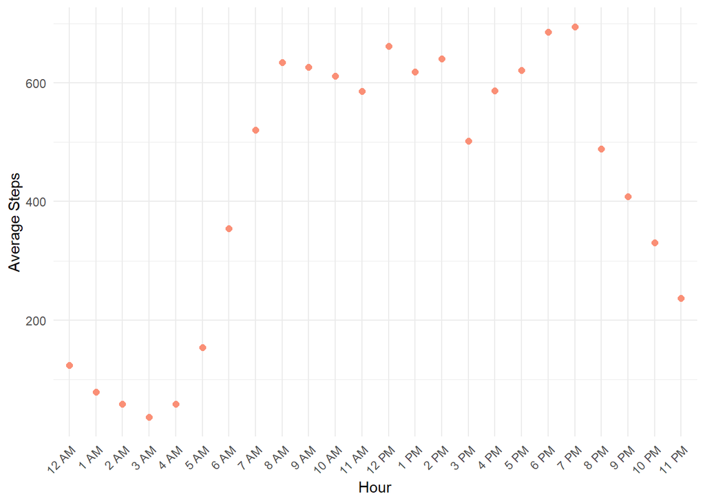

```r
chart_11 <- sorted_hourly_average_steps %>%
  mutate(Hour_simple = factor(Hour_simple, levels = unique(Hour_simple))) %>% ## keeping the order of the table
  ggplot(aes(x = Hour_simple, y = average_hourly_steps)) +
  geom_point(size = 2, color = "#fa8f76") +
  scale_x_discrete(guide = guide_axis(angle = 45)) + labs(x='Hour', y= 'Average Steps') +
  theme_minimal()
ggsave("hourly_steps.jpeg", plot=chart_11, path = '~/bellabeat_project/Figures')
chart_11
```

## Sleeping data

Daily sleeping data

```r
# reading data

dailySleep <- read.csv("~/bellabeat_project/Clean_tables/sleepDay_clean.csv")

# explore data
##glimpse(dailySteps)
dailySleep$Id <- as.character(dailySleep$Id)
##skimr::skim(dailySleep)
```

Minute sleeping data

```r
# reading data

minuteSleep <- read.csv("~/bellabeat_project/Clean_tables/minuteSleep_clean.csv")

# explore data
##glimpse(minuteSleep)
minuteSleep$Id <- as.character(minuteSleep$Id)
minuteSleep$Id <- as.character(minuteSleep$LogId)
##skimr::skim(minuteSleep)

cat('Dates of entries:', levels(as.factor(minuteSleep$Date)))
```

```
## Dates of entries: 3/12/2016 4/12/2016 5/12/2016
```

```r
minuteSleep$Hour_simple <- paste(sub(':.*$','', minuteSleep$Hour), minuteSleep$AM_PM)
##head(minuteSleep)
```

#### Average hourly sleeping values

```r
hourly_average_sleeping <-
  minuteSleep %>% group_by(Hour_simple) %>%  summarize(average_hourly_sleep = mean(Value))

sorted_hourly_average_sleeping <- hourly_average_sleeping %>% arrange(factor(Hour_simple, levels = c('12 AM', '1 AM', '2 AM', '3 AM', '4 AM', '5 AM', '6 AM', '7 AM', '8 AM', '9 AM', '10 AM', '11 AM', '12 PM', '1 PM', '2 PM', '3 PM', '4 PM', '5 PM', '6 PM', '7 PM', '8 PM', '9 PM', '10 PM', '11 PM')))
kable(sorted_hourly_average_sleeping)
```

| Hour_simple | average_hourly_sleep |
| --- | --- |
| 12 AM | 1.074822 |
| 1 AM | 1.071545 |
| 2 AM | 1.075201 |
| 3 AM | 1.061457 |
| 4 AM | 1.069374 |
| 5 AM | 1.069767 |
| 6 AM | 1.101919 |
| 7 AM | 1.118418 |
| 8 AM | 1.128302 |
| 9 AM | 1.089491 |
| 10 AM | 1.114691 |
| 11 AM | 1.168033 |
| 12 PM | 1.188235 |
| 1 PM | 1.150848 |
| 2 PM | 1.115799 |
| 3 PM | 1.179834 |
| 4 PM | 1.160873 |
| 5 PM | 1.154762 |
| 6 PM | 1.337921 |
| 7 PM | 1.252131 |
| 8 PM | 1.343703 |
| 9 PM | 1.219897 |
| 10 PM | 1.161274 |
| 11 PM | 1.100176 |

### Correlation between sleeping values and hour

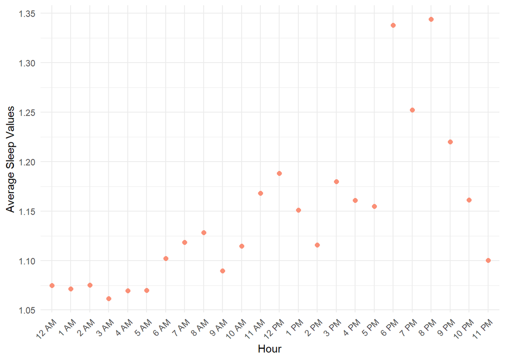

```r
chart_12 <- sorted_hourly_average_sleeping %>%
  mutate(Hour_simple = factor(Hour_simple, levels = unique(Hour_simple))) %>% ## keeping the order of the table
  ggplot(aes(x = Hour_simple, y = average_hourly_sleep)) +
  geom_point(size = 2, color = "#fa8f76") +
  scale_x_discrete(guide = guide_axis(angle = 45)) + labs(x='Hour', y= 'Average Sleep Values') +
  theme_minimal()
ggsave("hourly_sleep.jpeg", plot=chart_12, path = '~/bellabeat_project/Figures')
chart_12
```

## Analyzing heartrate

### Heartrate data

```r
# reading data

heartrates <- read.csv("~/bellabeat_project/Clean_tables/heartrates_clean.csv")

# explore data
##glimpse(heartrates)
heartrates$Id <- as.character(heartrates$Id)
##skimr::skim(heartrates)
devices_with_heartrate <- n_distinct(heartrates$Id)
cat('Dates of entries:', levels(as.factor(heartrates$Date)))
```

```
## Dates of entries: 3/12/2016 4/12/2016 5/12/2016
```

```r
heartrates$Hour_simple <- paste(sub(':.*$','', heartrates$Hour), heartrates$AM_PM)
##head(heartrates)
```

Heart rate is how many times our heart beats in 60 seconds. This number can go up or down as we go through your day and it is in correlation with our activity. From the 35 fitbits only 15 equipment registered the heartrate. We can assume that only their fitbit were able to measure and register the heartrate in every 5 seconds.

### Hourly average heartrates

```r
hourly_average_heartrates <-
  heartrates %>% group_by(Hour_simple) %>%  summarize(average_hourly_heartrate = mean(Value))

sorted_hourly_average_heartrates <- hourly_average_heartrates %>% arrange(factor(Hour_simple, levels = c('12 AM', '1 AM', '2 AM', '3 AM', '4 AM', '5 AM', '6 AM', '7 AM', '8 AM', '9 AM', '10 AM', '11 AM', '12 PM', '1 PM', '2 PM', '3 PM', '4 PM', '5 PM', '6 PM', '7 PM', '8 PM', '9 PM', '10 PM', '11 PM')))
kable(sorted_hourly_average_heartrates)
```

| Hour_simple | average_hourly_heartrate |
| --- | --- |
| 12 AM | 68.93492 |
| 1 AM | 67.88908 |
| 2 AM | 65.46205 |
| 3 AM | 62.52674 |
| 4 AM | 61.53227 |
| 5 AM | 64.45584 |
| 6 AM | 73.84528 |
| 7 AM | 76.16495 |
| 8 AM | 78.27200 |
| 9 AM | 81.52775 |
| 10 AM | 81.42794 |
| 11 AM | 81.90180 |
| 12 PM | 84.73134 |
| 1 PM | 82.61852 |
| 2 PM | 83.25638 |
| 3 PM | 82.09721 |
| 4 PM | 87.02281 |
| 5 PM | 85.46114 |
| 6 PM | 86.44407 |
| 7 PM | 85.19731 |
| 8 PM | 80.71749 |
| 9 PM | 77.06159 |
| 10 PM | 74.26154 |
| 11 PM | 71.23212 |

### Correalation between heartrates and hour

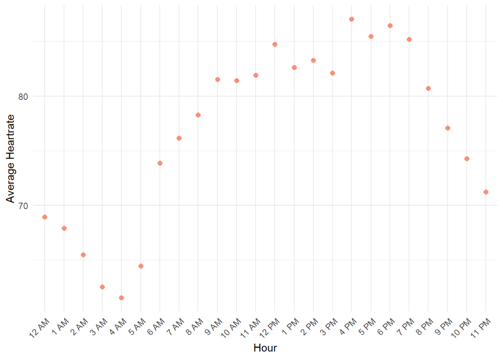

```r
chart_13 <- sorted_hourly_average_heartrates %>%
  mutate(Hour_simple = factor(Hour_simple, levels = unique(Hour_simple))) %>% ## keeping the order of the table
  ggplot(aes(x = Hour_simple, y = average_hourly_heartrate)) +
  geom_point(size = 2, color = "#fa8f76") +
  scale_x_discrete(guide = guide_axis(angle = 45)) + labs(x='Hour', y= 'Average Heartrate') +
  theme_minimal()
ggsave("hourly_heartrates.jpeg", plot=chart_13, path = '~/bellabeat_project/Figures')
chart_13
```

### Correlation between sleep and heartrate

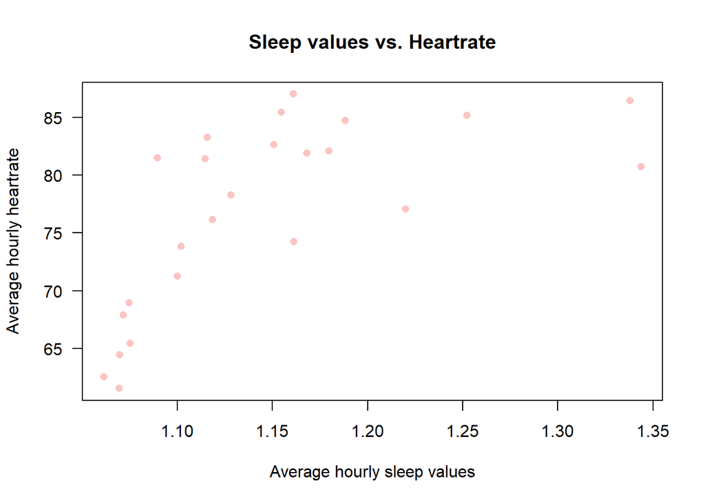

```r
sleep_and_heartrate <- inner_join(sorted_hourly_average_sleeping, sorted_hourly_average_heartrates, by='Hour_simple' )
##kable(sleep_and_heartrate)


chart_14 <- plot(average_hourly_heartrate ~ average_hourly_sleep,
     data = sleep_and_heartrate,
     main = "Sleep values vs. Heartrate",
     xlab = "Average hourly sleep values",
     ylab = "Average hourly heartrate",
     pch = 16,
     col = rgb(242,92,84, maxColorValue = 255, alpha=90),
     las =1)
```

```r
jpeg(file="~/bellabeat_project/Figures/sleep_vs_heartrate.jpeg")
chart_14
```

```r
dev.off()
```

```r
cor(sleep_and_heartrate$average_hourly_sleep, sleep_and_heartrate$average_hourly_heartrate)
```

```
## [1] 0.6516047
```

We can see that there is a clear correlation between sleeping data and the heartrate.

## Analyzing METs

A MET is a ratio of our working metabolic rate relative to the resting metabolic rate. Metabolic rate is the rate of energy expended per unit of time. It’s one way to describe the intensity of an exercise or activity.

One MET is the energy we spend sitting at rest — resting or basal metabolic rate. So, an activity with a MET value of 4 means we are exerting four times the energy than we would if you were sitting still.

### METs Data

```r
# reading data

mets <- read.csv("~/bellabeat_project/Clean_tables/minuteMETsNarrow_clean.csv")

# explore data
##glimpse(mets)
mets$Id <- as.character(mets$Id)
##skimr::skim(mets)

cat('Dates of entries:', levels(as.factor(heartrates$Date)))
```

```
## Dates of entries: 3/12/2016 4/12/2016 5/12/2016
```

```r
mets$Hour_simple <- paste(sub(':.*$','', mets$Hour), mets$AM_PM)
##head(mets)
```

### Hourly average METs

```r
hourly_average_mets <-
  mets %>% group_by(Hour_simple) %>%  summarize(average_hourly_mets = mean(METs))

sorted_hourly_average_mets <- hourly_average_mets %>% arrange(factor(Hour_simple, levels = c('12 AM', '1 AM', '2 AM', '3 AM', '4 AM', '5 AM', '6 AM', '7 AM', '8 AM', '9 AM', '10 AM', '11 AM', '12 PM', '1 PM', '2 PM', '3 PM', '4 PM', '5 PM', '6 PM', '7 PM', '8 PM', '9 PM', '10 PM', '11 PM')))
kable(sorted_hourly_average_mets)
```

| Hour_simple | average_hourly_mets |
| --- | --- |
| 12 AM | 16.45736 |
| 1 AM | 14.70245 |
| 2 AM | 13.52940 |
| 3 AM | 12.21088 |
| 4 AM | 12.61138 |
| 5 AM | 17.15478 |
| 6 AM | 23.89460 |
| 7 AM | 25.40948 |
| 8 AM | 27.28587 |
| 9 AM | 28.39394 |
| 10 AM | 28.15828 |
| 11 AM | 27.63663 |
| 12 PM | 28.65055 |
| 1 PM | 28.26195 |
| 2 PM | 29.02818 |
| 3 PM | 26.42729 |
| 4 PM | 28.19999 |
| 5 PM | 29.20896 |
| 6 PM | 29.65016 |
| 7 PM | 29.74707 |
| 8 PM | 26.30693 |
| 9 PM | 24.19276 |
| 10 PM | 22.73881 |
| 11 PM | 19.78907 |

### Correalation between METs and hour

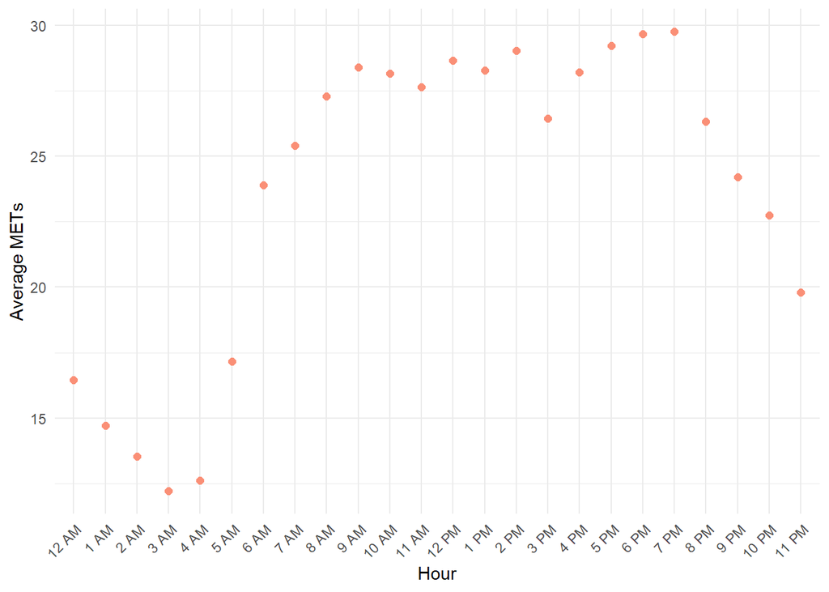

```r
chart_15 <- sorted_hourly_average_mets %>%
  mutate(Hour_simple = factor(Hour_simple, levels = unique(Hour_simple))) %>% ## keeping the order of the table
  ggplot(aes(x = Hour_simple, y = average_hourly_mets)) +
  geom_point(size = 2, color = "#fa8f76") +
  scale_x_discrete(guide = guide_axis(angle = 45)) + labs(x='Hour', y= 'Average METs') +
  theme_minimal()
ggsave("hourly_mets.jpeg", plot=chart_15, path = '~/bellabeat_project/Figures')
chart_15
```

### Correlataions between hourly intensities, calories, steps, heartrate and METs

```r
sorted_hourly_average_intensities
```

```
## # A tibble: 24 × 2
##    Hour_simple average_hourly_intensities
##    <chr>                            <dbl>
##  1 12 AM                             7.27
##  2 1 AM                              5.44
##  3 2 AM                              4.24
##  4 3 AM                              2.87
##  5 4 AM                              3.13
##  6 5 AM                             10.5
##  7 6 AM                             17.0
##  8 7 AM                             19.5
##  9 8 AM                             24.1
## 10 9 AM                             24.4
## # ℹ 14 more rows
```

```r
merged_cal_int <- inner_join(sorted_hourly_average_calories, sorted_hourly_average_intensities, by='Hour_simple')
merged_cal_int_steps <- inner_join(merged_cal_int, sorted_hourly_average_steps, by='Hour_simple')
merged_cal_int_steps_mets <- inner_join(merged_cal_int_steps, sorted_hourly_average_mets, by='Hour_simple')
merged_results <- inner_join(merged_cal_int_steps_mets, sorted_hourly_average_heartrates)

kable(merged_results)
```

| Hour_simple | average_hourly_calories | average_hourly_intensities | average_hourly_steps | average_hourly_mets | average_hourly_heartrate |
| --- | --- | --- | --- | --- | --- |
| 12 AM | 81.77760 | 7.274354 | 123.91964 | 16.45736 | 68.93492 |
| 1 AM | 78.82766 | 5.439791 | 78.67736 | 14.70245 | 67.88908 |
| 2 AM | 76.19014 | 4.241590 | 58.75626 | 13.52940 | 65.46205 |
| 3 AM | 73.13842 | 2.867924 | 36.36872 | 12.21088 | 62.52674 |
| 4 AM | 77.12813 | 3.127737 | 58.59497 | 12.61138 | 61.53227 |
| 5 AM | 91.42191 | 10.511696 | 153.87185 | 17.15478 | 64.45584 |
| 6 AM | 108.45527 | 17.036244 | 354.47566 | 23.89460 | 73.84528 |
| 7 AM | 113.74119 | 19.488180 | 520.68780 | 25.40948 | 76.16495 |
| 8 AM | 121.00089 | 24.055378 | 634.39983 | 27.28587 | 78.27200 |
| 9 AM | 123.44356 | 24.352390 | 626.78896 | 28.39394 | 81.52775 |
| 10 AM | 122.48779 | 24.204683 | 611.60141 | 28.15828 | 81.42794 |
| 11 AM | 122.77778 | 23.457338 | 586.09085 | 27.63663 | 81.90180 |
| 12 PM | 128.18454 | 25.735341 | 662.24773 | 28.65055 | 84.73134 |
| 1 PM | 123.93719 | 24.133499 | 618.30144 | 28.26195 | 82.61852 |
| 2 PM | 126.84786 | 24.781893 | 640.80386 | 29.02818 | 83.25638 |
| 3 PM | 118.14699 | 20.807660 | 502.36877 | 26.42729 | 82.09721 |
| 4 PM | 124.18359 | 22.812808 | 586.83377 | 28.19999 | 87.02281 |
| 5 PM | 130.97784 | 26.135004 | 621.04931 | 29.20896 | 85.46114 |
| 6 PM | 132.91620 | 26.239617 | 685.69717 | 29.65016 | 86.44407 |
| 7 PM | 133.78208 | 27.308247 | 694.17581 | 29.74707 | 85.19731 |
| 8 PM | 115.17753 | 20.681223 | 488.65638 | 26.30693 | 80.71749 |
| 9 PM | 106.50863 | 17.919483 | 408.65544 | 24.19276 | 77.06159 |
| 10 PM | 99.04089 | 15.000000 | 330.57020 | 22.73881 | 74.26154 |
| 11 PM | 88.49758 | 11.646512 | 237.42438 | 19.78907 | 71.23212 |

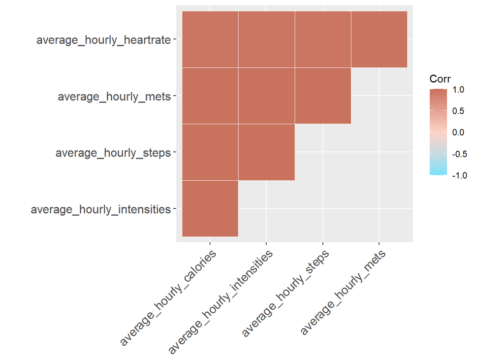

```r
cor_df = merged_results[-1]

chart_16 <- ggcorrplot(cor(cor_df), method = 'square', type = 'upper', outline.color = "white",
  ggtheme = ggplot2::theme_gray,
  colors = c("#76e1fa", "#fdd2c8", "#c8725e"))

chart_16
```

```r
ggsave("performance_correlation_matrix.jpeg", plot=chart_16, path = '~/bellabeat_project/Figures')
```

## Analyzing Weight Logs

### Weight Logs Data

```r
# reading data

weight_Logs <- read.csv("~/bellabeat_project/Clean_tables/weightLogInfo_clean.csv")

# explore data
##glimpse(weight_Logs)
weight_Logs$Id <- as.character(weight_Logs$Id)
##skimr::skim(weight_Logs)
```

### Number of logs, weight and BMI by Id

```r
weight_data_by_id <- weight_Logs %>% group_by(Id) %>%  summarize(count_weight_logs = n(), average_weight_kg = mean(WeightKg), bmi = mean(BMI), manual_report = sum(IsManualReport == "True"), not_manual_report=sum(IsManualReport == "False"))
weight_data_by_id$report_type <- case_when(weight_data_by_id$manual_report != 0 ~ 'manual', weight_data_by_id$not_manual_report !=0 ~ 'not manual', weight_data_by_id$manual_report != 0 & weight_data_by_id$not_manual_report != 0 ~'both')
kable(weight_data_by_id)
```

| Id | count_weight_logs | average_weight_kg | bmi | manual_report | not_manual_report | report_type |
| --- | --- | --- | --- | --- | --- | --- |
| 1503960366 | 3 | 52.83333 | 22.75667 | 3 | 0 | manual |
| 1927972279 | 2 | 131.55000 | 46.85500 | 0 | 2 | not manual |
| 2347167796 | 1 | 63.40000 | 24.77000 | 1 | 0 | manual |
| 2873212765 | 4 | 56.97500 | 21.56000 | 4 | 0 | manual |
| 2891001357 | 1 | 88.40000 | 25.03000 | 1 | 0 | manual |
| 4319703577 | 2 | 72.35000 | 27.41500 | 2 | 0 | manual |
| 4445114986 | 1 | 92.40000 | 35.01000 | 1 | 0 | manual |
| 4558609924 | 6 | 69.60000 | 27.20167 | 6 | 0 | manual |
| 4702921684 | 1 | 99.70000 | 26.11000 | 1 | 0 | manual |
| 5577150313 | 1 | 90.70000 | 28.00000 | 0 | 1 | not manual |
| 6962181067 | 43 | 61.63256 | 24.06093 | 43 | 0 | manual |
| 8253242879 | 1 | 75.60000 | 29.55000 | 1 | 0 | manual |
| 8877689391 | 32 | 85.29688 | 25.53469 | 0 | 32 | not manual |

```r
log_type <- weight_data_by_id %>% group_by(report_type) %>% summarize(count_type = n())
kable(log_type)
```

| report_type | count_type |
| --- | --- |
| manual | 10 |
| not manual | 3 |

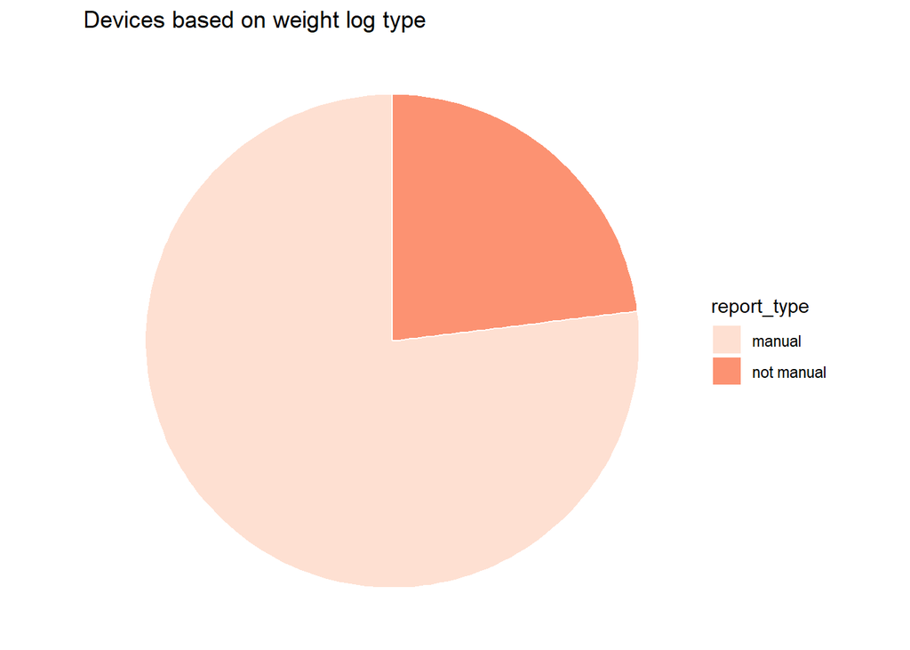

```r
chart_17 <- ggplot(log_type, aes(x="", y=count_type, fill=report_type)) +
  geom_bar(stat="identity", width=1, color="white") +
  coord_polar("y", start=0) +
  scale_fill_brewer(palette='Reds') +
  scale_color_brewer(palette='Reds') +
  ggtitle("Devices based on weight log type") +
  theme_void()
ggsave("weight_device_type.jpeg", plot=chart_17, path = '~/bellabeat_project/Figures')
chart_17
```

### Number of manual reports

```r
log_types <- weight_Logs %>% group_by(IsManualReport) %>%  summarize(manual = n())
kable(log_types)
```

| IsManualReport | manual |
| --- | --- |
| False | 35 |
| True | 63 |

## Summarizing hourly data per user device

```r
calories_by_id <- hourlyCalories_clean %>% group_by(Id) %>%  summarize(average_calories = mean(Calories), total_calories = sum(Calories))
##head(calories_by_id)
intensities_by_id <- hourlyIntensities %>% group_by(Id) %>%  summarize(average_intensities = mean(TotalIntensity))
##head(intensities_by_id)
mets_by_id <- mets %>% group_by(Id) %>%  summarize(average_mets = mean(METs))
##head(mets_by_id)
steps_by_id <- hourlySteps %>% group_by(Id) %>%  summarize(average_hourly_steps = mean(StepTotal), total_steps = sum(StepTotal))
##head(steps_by_id)

summarizing_by_id <- left_join(calories_by_id, intensities_by_id, by="Id") %>% left_join(.,mets_by_id, by="Id") %>% left_join(.,steps_by_id, by="Id")

kable(summarizing_by_id)
```

| Id | average_calories | total_calories | average_intensities | average_mets | average_hourly_steps | total_steps |
| --- | --- | --- | --- | --- | --- | --- |
| 1503960366 | 89.63981 | 92329 | 23.420242 | 31.21759 | 672.3652 | 780616 |
| 1624580081 | 67.75575 | 52985 | 12.052260 | 23.60046 | 365.2296 | 313367 |
| 1644430081 | 139.23486 | 131020 | 19.623441 | 25.53089 | 459.4724 | 449364 |
| 1844505072 | 84.90887 | 34473 | 14.008064 | 18.90619 | 313.6906 | 130809 |
| 1927972279 | 117.06785 | 79372 | 14.675147 | 20.64495 | 312.8621 | 199606 |
| 2022484408 | 141.22044 | 114671 | 32.250000 | 31.01463 | 867.2573 | 741505 |
| 2026352035 | 71.13452 | 59753 | 14.450667 | 21.96018 | 278.6529 | 309862 |
| 2320127002 | 84.83704 | 45812 | 14.983936 | 20.72466 | 346.9283 | 198443 |
| 2347167796 | 101.90568 | 78875 | 22.459716 | 26.38115 | 572.8269 | 493204 |
| 2873212765 | 91.50802 | 85560 | 22.011208 | 29.75366 | 503.8361 | 491744 |
| 2891001357 | 93.33333 | 1120 | 10.000000 | 11.66667 | 30.0000 | 360 |
| 3372868164 | 90.19385 | 67465 | 20.576687 | 25.99020 | 387.5995 | 321320 |
| 3977333714 | 73.31698 | 55281 | 22.199409 | 26.72000 | 571.3231 | 503907 |
| 4020332650 | 142.74010 | 82932 | 15.183267 | 20.87408 | 341.4963 | 185091 |
| 4057192912 | 102.33929 | 22924 | 9.889952 | 20.54461 | 325.4698 | 75509 |
| 4319703577 | 100.05440 | 86447 | 18.523377 | 24.20550 | 440.9363 | 429472 |
| 4388161847 | 140.45848 | 77814 | 20.385487 | 25.09176 | 551.4497 | 317635 |
| 4445114986 | 100.97972 | 99566 | 14.612220 | 21.93868 | 269.5005 | 296720 |
| 4558609924 | 96.49819 | 79804 | 19.951117 | 22.83222 | 429.3386 | 377818 |
| 4702921684 | 139.84929 | 137332 | 19.073265 | 25.32754 | 500.7732 | 507784 |
| 5553957443 | 87.79070 | 83050 | 18.384522 | 24.41481 | 438.8087 | 481812 |
| 5577150313 | 165.34437 | 174769 | 30.604546 | 31.99863 | 489.7312 | 533807 |
| 6117666160 | 109.99281 | 91734 | 21.998569 | 22.70291 | 490.0523 | 412624 |
| 6290855005 | 139.73492 | 76435 | 20.396887 | 23.01925 | 487.5079 | 277392 |
| 6391747486 | 91.68657 | 6143 | 6.954546 | 12.28028 | 182.3030 | 12032 |
| 6775888955 | 148.42699 | 67089 | 23.864103 | 23.99323 | 491.1493 | 207265 |
| 6962181067 | 103.48854 | 99349 | 25.734597 | 27.20609 | 690.8801 | 743387 |
| 7007744171 | 136.34074 | 110436 | 29.591808 | 27.69326 | 742.9522 | 636710 |
| 7086361926 | 121.59365 | 111015 | 21.888071 | 25.79474 | 537.9867 | 484188 |
| 8053475328 | 157.35287 | 136897 | 32.968000 | 35.88243 | 982.0289 | 917215 |
| 8253242879 | 90.20261 | 27602 | 16.745098 | 25.50474 | 473.6877 | 150159 |
| 8378563200 | 143.97670 | 154487 | 17.038860 | 26.73953 | 437.4949 | 513619 |
| 8583815059 | 125.98387 | 78110 | 15.945946 | 21.73408 | 369.3130 | 235991 |
| 8792009665 | 100.37523 | 54303 | 10.830588 | 18.77252 | 192.3806 | 103116 |
| 8877689391 | 177.90545 | 173102 | 30.911111 | 35.20787 | 994.6900 | 1023536 |

### Correlation between performance data

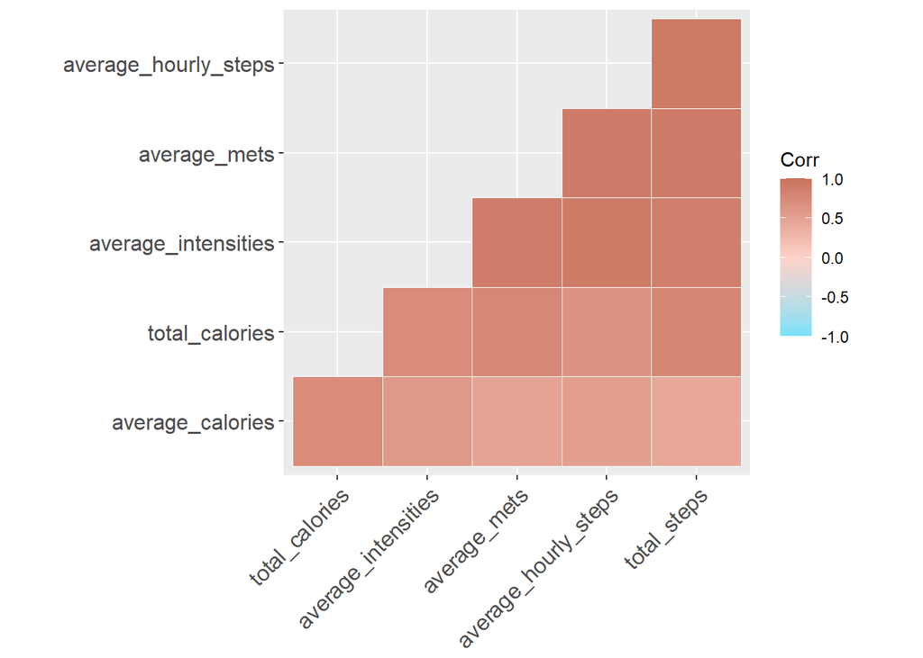

```r
cor_df_2 = summarizing_by_id[-1]

chart_18 <- ggcorrplot(cor(cor_df_2), method = 'square', type = 'lower', outline.color = "white",
  ggtheme = ggplot2::theme_gray,
  colors = c("#76e1fa", "#fdd2c8", "#c8725e"))

chart_18
```

```r
ggsave("activity_and_performance_correlation_matrix.jpeg", plot=chart_18, path = '~/bellabeat_project/Figures')
```

## Analyzing functions

```r
average_heartrate_by_id <- heartrates %>% group_by(Id) %>%  summarize(average_heartrate = mean(Value))
func_heartrate <- full_join(summarizing_by_id, average_heartrate_by_id, by="Id")
func_bmi <- full_join(func_heartrate, weight_data_by_id, by="Id")
func_days <- full_join(func_bmi, usage_days_by_id, by="Id")
func_all <- full_join(func_days, total_entries_by_id, by="Id")
kable(func_all)
```

| Id | average_calories | total_calories | average_intensities | average_mets | average_hourly_steps | total_steps | average_heartrate | count_weight_logs | average_weight_kg | bmi | manual_report | not_manual_report | report_type | count_activity_dates | count_by_id |
| --- | --- | --- | --- | --- | --- | --- | --- | --- | --- | --- | --- | --- | --- | --- | --- |
| 1503960366 | 89.63981 | 92329 | 23.420242 | 31.21759 | 672.3652 | 780616 | NA | 3 | 52.83333 | 22.75667 | 3 | 0 | manual | 3 | 50 |
| 1624580081 | 67.75575 | 52985 | 12.052260 | 23.60046 | 365.2296 | 313367 | NA | NA | NA | NA | NA | NA | NA | 3 | 50 |
| 1644430081 | 139.23486 | 131020 | 19.623441 | 25.53089 | 459.4724 | 449364 | NA | NA | NA | NA | NA | NA | NA | 2 | 40 |
| 1844505072 | 84.90887 | 34473 | 14.008064 | 18.90619 | 313.6906 | 130809 | NA | NA | NA | NA | NA | NA | NA | 2 | 36 |
| 1927972279 | 117.06785 | 79372 | 14.675147 | 20.64495 | 312.8621 | 199606 | NA | 2 | 131.55000 | 46.85500 | 0 | 2 | not manual | 2 | 33 |
| 2022484408 | 141.22044 | 114671 | 32.250000 | 31.01463 | 867.2573 | 741505 | 81.17289 | NA | NA | NA | NA | NA | NA | 2 | 43 |
| 2026352035 | 71.13452 | 59753 | 14.450667 | 21.96018 | 278.6529 | 309862 | 89.58447 | NA | NA | NA | NA | NA | NA | 2 | 43 |
| 2320127002 | 84.83704 | 45812 | 14.983936 | 20.72466 | 346.9283 | 198443 | NA | NA | NA | NA | NA | NA | NA | 2 | 40 |
| 2347167796 | 101.90568 | 78875 | 22.459716 | 26.38115 | 572.8269 | 493204 | 77.44978 | 1 | 63.40000 | 24.77000 | 1 | 0 | manual | 2 | 33 |
| 2873212765 | 91.50802 | 85560 | 22.011208 | 29.75366 | 503.8361 | 491744 | NA | 4 | 56.97500 | 21.56000 | 4 | 0 | manual | 2 | 43 |
| 2891001357 | 93.33333 | 1120 | 10.000000 | 11.66667 | 30.0000 | 360 | NA | 1 | 88.40000 | 25.03000 | 1 | 0 | manual | 2 | 5 |
| 3372868164 | 90.19385 | 67465 | 20.576687 | 25.99020 | 387.5995 | 321320 | NA | NA | NA | NA | NA | NA | NA | 2 | 30 |
| 3977333714 | 73.31698 | 55281 | 22.199409 | 26.72000 | 571.3231 | 503907 | NA | NA | NA | NA | NA | NA | NA | 2 | 42 |
| 4020332650 | 142.74010 | 82932 | 15.183267 | 20.87408 | 341.4963 | 185091 | 82.41150 | NA | NA | NA | NA | NA | NA | 3 | 52 |
| 4057192912 | 102.33929 | 22924 | 9.889952 | 20.54461 | 325.4698 | 75509 | NA | NA | NA | NA | NA | NA | NA | 2 | 25 |
| 4319703577 | 100.05440 | 86447 | 18.523377 | 24.20550 | 440.9363 | 429472 | NA | 2 | 72.35000 | 27.41500 | 2 | 0 | manual | 3 | 43 |
| 4388161847 | 140.45848 | 77814 | 20.385487 | 25.09176 | 551.4497 | 317635 | 66.87181 | NA | NA | NA | NA | NA | NA | 3 | 34 |
| 4445114986 | 100.97972 | 99566 | 14.612220 | 21.93868 | 269.5005 | 296720 | NA | 1 | 92.40000 | 35.01000 | 1 | 0 | manual | 3 | 46 |
| 4558609924 | 96.49819 | 79804 | 19.951117 | 22.83222 | 429.3386 | 377818 | 81.46883 | 6 | 69.60000 | 27.20167 | 6 | 0 | manual | 2 | 43 |
| 4702921684 | 139.84929 | 137332 | 19.073265 | 25.32754 | 500.7732 | 507784 | NA | 1 | 99.70000 | 26.11000 | 1 | 0 | manual | 3 | 46 |
| 5553957443 | 87.79070 | 83050 | 18.384522 | 24.41481 | 438.8087 | 481812 | 70.35228 | NA | NA | NA | NA | NA | NA | 2 | 43 |
| 5577150313 | 165.34437 | 174769 | 30.604546 | 31.99863 | 489.7312 | 533807 | 70.38696 | 1 | 90.70000 | 28.00000 | 0 | 1 | not manual | 2 | 40 |
| 6117666160 | 109.99281 | 91734 | 21.998569 | 22.70291 | 490.0523 | 412624 | 83.98417 | NA | NA | NA | NA | NA | NA | 2 | 35 |
| 6290855005 | 139.73492 | 76435 | 20.396887 | 23.01925 | 487.5079 | 277392 | NA | NA | NA | NA | NA | NA | NA | 2 | 30 |
| 6391747486 | 91.68657 | 6143 | 6.954546 | 12.28028 | 182.3030 | 12032 | 84.13118 | NA | NA | NA | NA | NA | NA | 1 | 6 |
| 6775888955 | 148.42699 | 67089 | 23.864103 | 23.99323 | 491.1493 | 207265 | 95.12269 | NA | NA | NA | NA | NA | NA | 2 | 27 |
| 6962181067 | 103.48854 | 99349 | 25.734597 | 27.20609 | 690.8801 | 743387 | 79.98353 | 43 | 61.63256 | 24.06093 | 43 | 0 | manual | 3 | 45 |
| 7007744171 | 136.34074 | 110436 | 29.591808 | 27.69326 | 742.9522 | 636710 | 90.86328 | NA | NA | NA | NA | NA | NA | 2 | 38 |
| 7086361926 | 121.59365 | 111015 | 21.888071 | 25.79474 | 537.9867 | 484188 | NA | NA | NA | NA | NA | NA | NA | 2 | 43 |
| 8053475328 | 157.35287 | 136897 | 32.968000 | 35.88243 | 982.0289 | 917215 | NA | NA | NA | NA | NA | NA | NA | 2 | 42 |
| 8253242879 | 90.20261 | 27602 | 16.745098 | 25.50474 | 473.6877 | 150159 | NA | 1 | 75.60000 | 29.55000 | 1 | 0 | manual | 1 | 26 |
| 8378563200 | 143.97670 | 154487 | 17.038860 | 26.73953 | 437.4949 | 513619 | NA | NA | NA | NA | NA | NA | NA | 2 | 43 |
| 8583815059 | 125.98387 | 78110 | 15.945946 | 21.73408 | 369.3130 | 235991 | NA | NA | NA | NA | NA | NA | NA | 2 | 39 |
| 8792009665 | 100.37523 | 54303 | 10.830588 | 18.77252 | 192.3806 | 103116 | 74.48364 | NA | NA | NA | NA | NA | NA | 2 | 34 |
| 8877689391 | 177.90545 | 173102 | 30.911111 | 35.20787 | 994.6900 | 1023536 | 85.16006 | 32 | 85.29688 | 25.53469 | 0 | 32 | not manual | 2 | 43 |

### Count of devices based on ids

```r
devices_total <- n_distinct(func_all$Id)
devices_total
```

```
## [1] 35
```

### Portion of devices with heartrate function

```r
func_all$Heartrate_detecting <- ifelse(is.na(func_all$average_heartrate),0,1)
devices_heartrate <- sum(func_all$Heartrate_detecting)
devices_heartrate
```

```
## [1] 15
```

#### Portion of devices with weightlog function

```r
func_all$Weight_detecting <- ifelse(is.na(func_all$bmi),0,1)
devices_bmi <- sum(func_all$Weight_detecting)
devices_bmi
```

```
## [1] 13
```

### Portion of devices with both functions

```r
func_all$both_functions <- func_all$Heartrate_detecting + func_all$Weight_detecting
##glimpse(func_all)
devices_both <- nrow(func_all[func_all$both_functions == 2, ])
devices_both
```

```
## [1] 5
```

### Distribution of devices by function

```r
min_function <- nrow(func_all[func_all$both_functions == 0, ])
only_heartrate <- nrow(func_all[func_all$Heartrate_detecting == 1 & func_all$Weight_detecting == 0,])
only_heartrate
```

```
## [1] 10
```

```r
only_weight <- nrow(func_all[func_all$Heartrate_detecting == 0 & func_all$Weight_detecting == 1,])
only_weight
```

```
## [1] 8
```

```r
additional_functions <- c("No", "Heartrate", "WeightLog", "Both")
number_of_devices <- c(min_function, only_heartrate, only_weight, devices_both)

data_table <- data.frame(additional_functions, number_of_devices)
data_table$percent <- round(data_table$number_of_devices / sum(data_table$number_of_devices) * 100, 2)
kable(data_table)
```

| additional_functions | number_of_devices | percent |
| --- | --- | --- |
| No | 12 | 34.29 |
| Heartrate | 10 | 28.57 |
| WeightLog | 8 | 22.86 |
| Both | 5 | 14.29 |

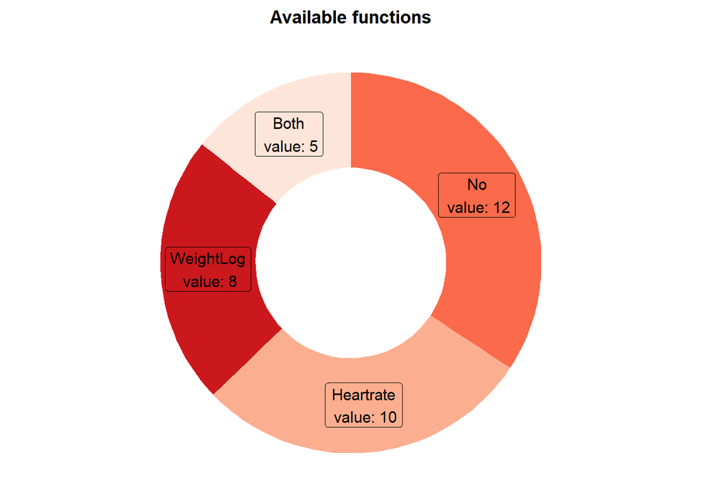

```r
# Computing the cumulative percentages
data_table$ymax = cumsum(data_table$percent)

# Computing the bottom of each rectangle
data_table$ymin = c(0, head(data_table$ymax, n=-1))

# Computing label position
data_table$labelPosition <- (data_table$ymax + data_table$ymin) / 2

# Computing the label
data_table$label <- paste0(data_table$additional_functions, "\n value: ", data_table$number_of_devices)

# Making the plot
chart_19 <- ggplot(data_table, aes(ymax=ymax, ymin=ymin, xmax=4, xmin=3, fill=additional_functions)) +
     geom_rect() +
     geom_label( x=3.5, aes(y=labelPosition, label=label), color="black", size=4) +
     coord_polar(theta="y") +
     xlim(c(2, 4)) +
     scale_fill_brewer(palette='Reds') +
     scale_color_brewer(palette='Reds') +
     ggtitle("Available functions") +
     theme_void() +
     theme(legend.position = "none", plot.title=element_text(hjust=0.5, vjust=0.5, face='bold'))
ggsave("devices_by_function.jpeg", plot=chart_19, path = '~/bellabeat_project/Figures')
chart_19
```

## Correlation-matrix on performance and available functions

```r
Data <- c('ActivityDays', 'Entries', 'TotalCalories', 'TotalSteps', 'AverageIntensities', 'AverageMETs')
Correlation_to_device_type <- c(cor(func_all$both_functions, func_all$count_activity_dates ), cor(func_all$both_functions, func_all$count_by_id ), cor(func_all$both_functions, func_all$total_calories), cor(func_all$both_functions, func_all$total_steps), cor(func_all$both_functions, func_all$average_intensities), cor(func_all$both_functions, func_all$average_mets))

cor_table <- data.frame(Data, Correlation_to_device_type)
kable(cor_table)
```

| Data | Correlation_to_device_type |
| --- | --- |
| ActivityDays | 0.1014351 |
| Entries | 0.0258390 |
| TotalCalories | 0.2330606 |
| TotalSteps | 0.2682868 |
| AverageIntensities | 0.2986226 |
| AverageMETs | 0.1670837 |

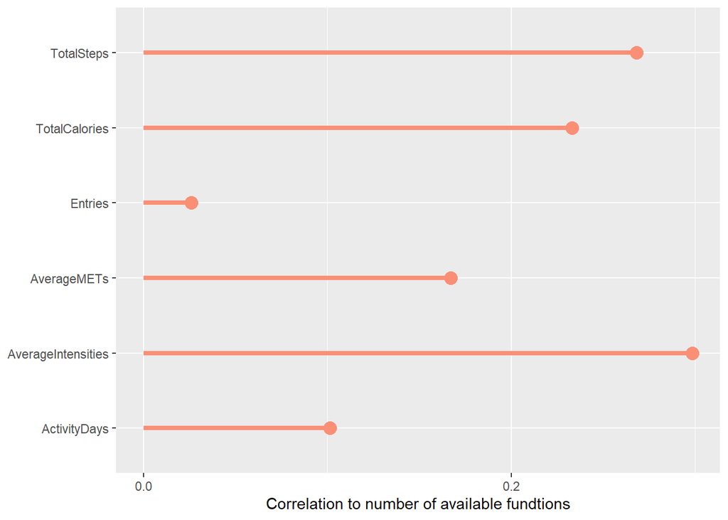

```r
chart_20 <- ggplot(cor_table, aes(x = Data, y = Correlation_to_device_type, color=Correlation_to_device_type)) +
  geom_segment(aes(x = Data, xend = Data, y = 0, yend = Correlation_to_device_type),
               color="#fa8f76", lwd = 1.5) +
  geom_point(size = 4, pch = 16, bg = "#fa8f76", color = "#fa8f76") +
  labs(y="Correlation to number of available fundtions", x=NULL) +
  scale_y_continuous(breaks = c(0,0.2,0.4,0.6,0.8,1))+
  coord_flip()
ggsave("cor_performance_functions.jpeg", plot=chart_20, path = '~/bellabeat_project/Figures')
chart_20
```

From the chart we can see that there is a correlation between the number of available functions, although it is not as strong as expected.

# Summarizing the analysation and answering the business questions

## The trends in the smart device usage

Based on the provided data, we can identify several trends and insights related to smart device usage. Here’s a breakdown of key trends:

### User Participation and Overall Usage

The analyzation shows that user participation was variable over the observed period, with a significant spike on Day 2. The number of users directly correlates with the number of entries (as seen in the higher number of entries on Day 2).

Entries per device ranged from 5 to 52, with an average of 37 entries, median of 40, and mode of 43. Devices with higher entries likely correspond to more active users or more frequent tracking of activities, suggesting some devices were used more intensively than others.This points to a divergence in device usage, with some devices seeing minimal usage while others were used extensively.

### Activity Correlations

A strong correlation (0.7268) was observed between calories burned and the number of entries, suggesting that devices that track calories tend to generate more entries. The high correlation between calories and entries points to an increase in activity and tracking as users engage more intensively with their devices, particularly on Day 2.

Activity measures (steps, calories, METs, etc.) were significantly higher between 7 AM and 7 PM, with a peak in the late afternoon and early evening. This suggests that activity levels are generally higher during the day, particularly in the hours after work or school, which may align with typical daily routines and peak physical activity times. The intensity of activity, as measured by metrics like steps and METs, seems to follow a clear daily rhythm, which is a common pattern for wearable fitness devices.

### Device Functionality and Performance

In summary, trends indicate that user participation, device features, and time-of-day activity all play key roles in shaping how users interact with their smart devices, and more active users tend to contribute more data, particularly around calories and activity metrics.

## How could these trends apply to Bellabeat customers?

### Opportunity: User Participation Drives Engagement and Data Collection

Trend: There was a significant increase in entries when the number of users increased, particularly on Day 2 when 25 users contributed to a high number of entries.

Implication for Bellabeat: Bellabeat should encourage users to engage with their devices regularly to increase data collection. This could be through targeted notifications, reminders, or gamified features that prompt users to log activities, track steps, and monitor other metrics. Higher user participation directly leads to more data and more insights for both the user and the company.

Strategy: Bellabeat could introduce features like daily or weekly challenges to encourage users to check in and engage with the device more frequently, leading to higher data logs and insights.

### Opportunity: Advanced Features Increase Device Usage

Implication for Bellabeat: Bellabeat’s devices, such as the Bellabeat Ivy, have built-in features like tracking menstrual cycles, activity, and sleep. The inclusion of additional health metrics like heart rate and stress levels could increase engagement, as users are more likely to track their progress and see value in their device when it monitors multiple aspects of their well-being.

Strategy: Bellabeat could emphasize multi-dimensional health tracking (e.g., incorporating heart rate tracking or advanced sleep analytics) to cater to users who seek comprehensive wellness data. Adding more in-depth analytics or personalized insights based on these features could appeal to Bellabeat’s target demographic, driving further engagement and use.

### Opportunity: Peak Activity Times Could Inform Product Features and Engagement

Trend: Activity intensity (e.g., steps, calories, and METs) was highest between 7 AM and 7 PM, particularly in the late afternoon and early evening.

Implication for Bellabeat: Understanding that customers are more active during certain times of the day can help Bellabeat optimize its notifications and reminders. This insight also suggests that Bellabeat could design features that encourage users to track their activity during these peak times (e.g., encouraging users to log their exercise, track steps, or engage with the app after work or in the evening).

Strategy: Bellabeat could implement activity reminders or notifications timed to when users are most likely to be active, such as reminders to log their steps or engage in short mindfulness exercises after a busy workday.

### Correlation Between Activity Metrics (Steps, Intensity, and Calories)

Trend: Strong correlations were found between steps, intensity, heart rate, and calories burned.

Implication for Bellabeat: Since Bellabeat’s customers are often focused on holistic wellness, these metrics could be bundled to create a more integrated user experience. By correlating these activity metrics, Bellabeat could provide users with personalized feedback on how their activity levels (e.g., steps or intensity) are impacting their overall well-being, especially in terms of calorie expenditure.

Strategy: Bellabeat could build a more seamless and informative experience that highlights how users’ activity levels impact their calorie burn and overall health. This could include tailored recommendations, such as increasing activity intensity or modifying daily habits to optimize fitness and well-being.

### Opportunity: Encouraging Comprehensive Health Tracking

Implication for Bellabeat: Bellabeat could consider expanding its product line to include features like heart rate tracking or weight monitoring, which are common in fitness-oriented wearables but still underrepresented in some wellness-focused devices. Offering these features could increase the overall engagement of users who are more fitness-focused or goal-driven.

Strategy: Bellabeat might consider adding heart rate tracking or weight logging to some of its devices or even releasing an upgraded version that includes these features. Doing so could help capture a larger segment of users who are seeking more detailed and actionable health insights, especially in a fitness or wellness context.

## Suggestions for marketing strategy

### Building Community

Bellabeat can create marketing campaigns that highlight the sense of community around their devices. For example, promoting user challenges (e.g., step challenges, mindfulness challenges) could encourage more users to participate and track their activity, creating a sense of shared experience.

### Promote Advanced Features to Boost Engagement

Bellabeat should emphasize the advanced tracking features in their marketing, particularly those related to heart rate monitoring, weight tracking, and comprehensive wellness tracking. Potential customers who are more serious about fitness or holistic health would be attracted to these features.

### Take adventage in timing of promotions and place

Bellabeat can capitalize on peak activity times with flash sales, limited-time promotions, or content targeted at users when they are most likely to be active and engaged (e.g., early evening when activity levels peak). Bellabeat could partner with fitness influencers or wellness coaches to show how the device helps track calories and overall activity levels.